# Seattle Pets: Explained

Oleksiy Anokhin

March 26, 2019

*This small project is a part of a weekly [**#TidyTuesday**](https://github.com/rfordatascience/tidytuesday) challenge. This time I will explore … Seattle pets.*

*My first question was - How many pets per zip code in Seattle?*

*In order to figure it out, I would like to merge a given dataset with `data(zipcode)` from `zipcode` package, using `left_join()`. It will allow to assign each zipcode to a specific GPS location*

| zip_code | number | city | state | latitude | longitude |
| --- | --- | --- | --- | --- | --- |
| 98115 | 4744 | Seattle | WA | 47.68382 | -122.3012 |
| 98103 | 4500 | Seattle | WA | 47.67135 | -122.3417 |
| 98117 | 3871 | Seattle | WA | 47.68592 | -122.3784 |
| 98125 | 2879 | Seattle | WA | 47.71665 | -122.3031 |
| 98122 | 2518 | Seattle | WA | 47.61157 | -122.3041 |
| 98107 | 2453 | Seattle | WA | 47.66747 | -122.3747 |

*Then I will visualize number of pets per zip code.*

[interactive chart not shown]

*Then I would like to see if there any trends in owning cats vs dogs. I started from cats.*

| zip_code | number | city | state | latitude | longitude |
| --- | --- | --- | --- | --- | --- |
| 98103 | 1655 | Seattle | WA | 47.67135 | -122.3417 |
| 98115 | 1626 | Seattle | WA | 47.68382 | -122.3012 |
| 98117 | 1344 | Seattle | WA | 47.68592 | -122.3784 |
| 98125 | 934 | Seattle | WA | 47.71665 | -122.3031 |
| 98122 | 931 | Seattle | WA | 47.61157 | -122.3041 |
| 98107 | 909 | Seattle | WA | 47.66747 | -122.3747 |

[interactive chart not shown]

*Now let’s explore dogs and map them.*

| zip_code | number | city | state | latitude | longitude |
| --- | --- | --- | --- | --- | --- |
| 98115 | 3111 | Seattle | WA | 47.68382 | -122.3012 |
| 98103 | 2845 | Seattle | WA | 47.67135 | -122.3417 |
| 98117 | 2524 | Seattle | WA | 47.68592 | -122.3784 |
| 98125 | 1939 | Seattle | WA | 47.71665 | -122.3031 |
| 98118 | 1754 | Seattle | WA | 47.54335 | -122.2750 |
| 98116 | 1660 | Seattle | WA | 47.57487 | -122.3939 |

[interactive chart not shown]

*I think it is obvious that people have more dogs in Seattle for some reason.*

*Now I would like to see how the registration went by month.*

*I start from converting data into more reliable format. From `chr` like `November 16 2018` to `int` like `Nov 2018`.*

| license_issue_date | species | number |
| --- | --- | --- |
| Apr 2003 | Cat | 1 |
| Feb 2004 | Dog | 1 |
| Feb 2006 | Cat | 1 |
| Mar 2008 | Dog | 1 |
| Dec 2008 | Dog | 1 |
| Mar 2011 | Dog | 1 |

*The chart will look like this:*

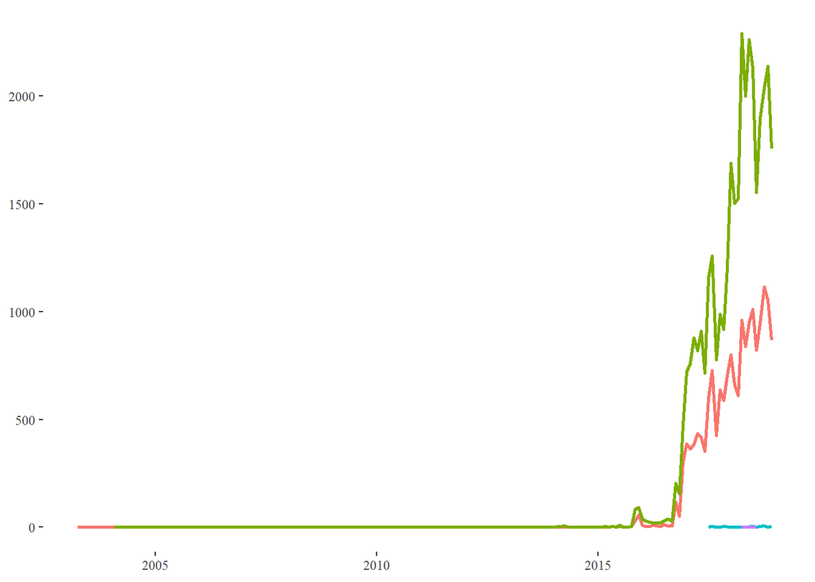

*As you can see, the active registering of pets in this dataset started after 2015, which raises questions what had happened before. I doubt that people did not have pets in Seattle before 2015? Maybe the city established new rules for such registration or something else?*

*Ok, let’s check data from 2015 only. BTW, I realized that there are not only cats and dogs in this datasets, but also pigs and goats(!!!). I noticed it, when I visualized data on a previous chart.*

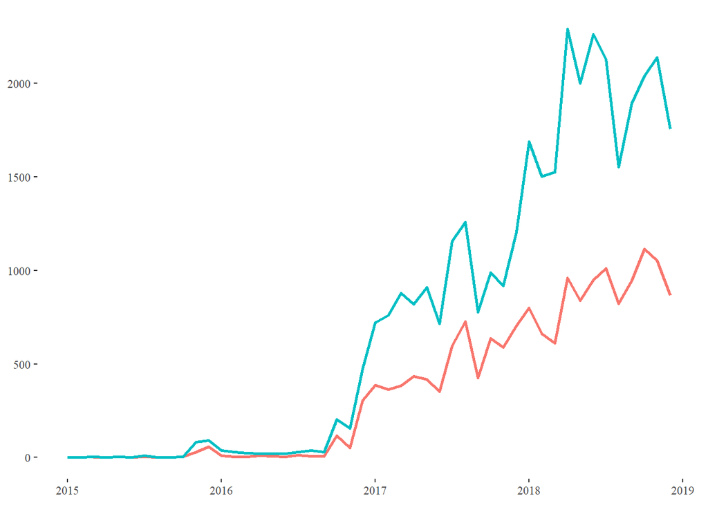

*As you can see, dogs prevail. More interesting that the pattern of registration is the same for cats and dogs. Not sure why though.*

*Ok, everybody visualized cats and dogs and their popular names. I was curious about names of goats and pigs? Any pattern here?*

| animals_name | species | number |
| --- | --- | --- |
| NA | Pig | 1 |
| Abelard | Goat | 1 |
| Aggie | Goat | 1 |
| Arya | Goat | 1 |
| Atticus | Pig | 1 |
| Beans | Goat | 1 |
| Brussels Sprout | Goat | 1 |
| Coconut | Pig | 1 |
| Darcy | Goat | 1 |
| Darla | Pig | 1 |
| Fawn | Goat | 1 |
| Fiona | Goat | 1 |
| Gavin | Goat | 1 |
| Grace | Goat | 1 |
| Grayson | Goat | 1 |
| Heidi | Goat | 2 |
| Holly | Goat | 1 |
| Junebug | Goat | 1 |
| Lilac | Goat | 1 |
| Linda | Goat | 1 |
| Lula | Goat | 1 |
| Magnolia | Goat | 1 |
| Margot | Goat | 1 |
| Max | Goat | 1 |
| Millie | Pig | 1 |
| Moppet | Goat | 1 |
| Nani | Goat | 1 |
| Olive | Goat | 1 |
| Othello | Pig | 1 |
| Pegasis | Goat | 1 |
| Pepina | Goat | 1 |
| Phyllis | Goat | 1 |
| Piper | Goat | 1 |
| Professor Nibblesworth | Goat | 1 |
| Ramsey | Goat | 1 |
| Robuchon | Goat | 1 |
| Sassy | Goat | 1 |
| Sister Bertrille | Goat | 1 |
| Squiggie | Goat | 1 |
| Tacoma | Goat | 1 |
| Tati | Goat | 1 |
| Teddy | Goat | 1 |
| Truffle | Goat | 1 |

*Ok, let’s at least visualize the most popular names of pets, as everybody did. I will filter by names with at least 100 times.*

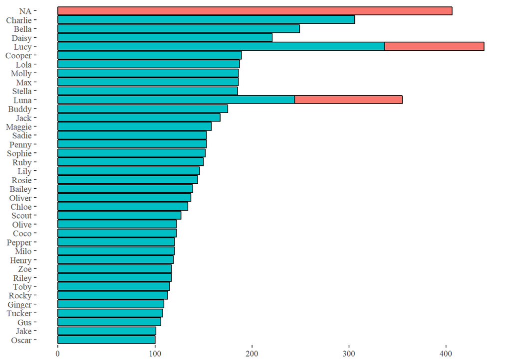

*It is interesting that so many cats are not registered with names. Why?*

**Conclusion**

*A pretty simple dataset, but still fun. I need a pig and I would call it Othello now.*

**Author’s Twitter**: OleksiyAnokhin